# ベイズモデルによるマーケティング現象のモデル化①

## (1) 階層ベイズロジットモデル

### データ

```r
setwd("D:/R_Appendix")
df1 <- read.csv("sec8_data1.csv") # ID付POSデータ
df2 <- read.csv("sec8_data2.csv") # 消費者属性データ
head(df1)
head(df2)
```

|  | PNL | Date | Product1 | Product2 | Product3 | Choice | Price1 | Price2 | Price3 | Disp1 | Disp2 | Disp3 | Ad1 | Ad2 | Ad3 |
| --- | --- | --- | --- | --- | --- | --- | --- | --- | --- | --- | --- | --- | --- | --- | --- |
| 1 | 100021 | 20000224 | 0 | 0 | 1 | 3 | 0.802817 | 0.846416 | 1 | 0 | 0 | 1 | 0 | 0 | 0 |
| 2 | 100021 | 20000312 | 0 | 0 | 1 | 3 | 1.000000 | 0.846416 | 1 | 0 | 0 | 1 | 0 | 0 | 0 |
| 3 | 100021 | 20000401 | 0 | 0 | 1 | 3 | 0.908451 | 0.899659 | 1 | 0 | 1 | 1 | 0 | 0 | 0 |
| 4 | 100021 | 20000406 | 0 | 0 | 1 | 3 | 0.908451 | 0.846416 | 1 | 0 | 1 | 1 | 0 | 0 | 0 |
| 5 | 100021 | 20000427 | 0 | 0 | 1 | 3 | 1.000000 | 0.948805 | 1 | 0 | 0 | 1 | 0 | 0 | 0 |
| 6 | 100021 | 20000518 | 0 | 0 | 1 | 3 | 0.908451 | 1.000000 | 1 | 0 | 0 | 1 | 0 | 0 | 0 |

**醤油のID付POSデータ**（8.2.4節，p.146）

- PNL：消費者パネルID
- Date：購買日
- Product1 ~ 3：購買の有無（0＝購買なし，1＝購買あり）
- Choice：購買ブランド
- Price1 ~ 3：価格掛率
- Disp1 ~ 3：山積み陳列実施の有無
- Ad1 ~ 3：チラシ掲載の有無

|  | PNL | age | family |
| --- | --- | --- | --- |
| 1 | 100021 | 59 | 3 |
| 2 | 100072 | 53 | 5 |
| 3 | 100092 | 51 | 5 |
| 4 | 100118 | 48 | 5 |
| 5 | 100161 | 55 | 2 |
| 6 | 100176 | 44 | 4 |

**消費者属性データ**（8.2.4節，p.146）

- PNL：消費者パネルID
- age：年齢
- family：家族人数

### モデル

効用関数： $\boldsymbol{U}_i = \boldsymbol{x}_i \boldsymbol{\beta}_i + \boldsymbol{\varepsilon}_i$  
階層モデル： $\boldsymbol{\beta}_i = \boldsymbol{\Theta}^t \boldsymbol{z}_i + \boldsymbol{\eta}_i$

（詳細は教科書p.146を参照）

### 分析（モデル1）

#### データの前処理

```r
library(bayesm)
id <- df2$PNL # 消費者パネルIDの抽出
n <- length(id) # 消費者パネル数
j <- 3  # 商品の個数
k <- 3  # マーケティング変数の個数

# 観測モデル（多項ロジットモデル）の目的・説明変数
yxdata <- list()  # 各消費者の購買データを list 形式に変換
for (i in 1:n) {
  data <- df1[df1$PNL == id[i],]
  ydata <- data$Choice
  xdata <- createX(p = j, na = k, nd = NULL, Xa = data[,7:15], Xd = NULL, base = 3)
  yxdata[[i]] <- list(y = ydata, X = xdata)
}

# 階層モデルの説明変数（平均0に基準化）
zdata <- scale(df2[, c("age", "family")], center = TRUE, scale = FALSE)

# 全データのリスト化
dataset <- list(p = j, lgtdata = yxdata, Z = zdata)
```

- `createX`：bayesm パッケージのロジットモデル推定のために説明変数を変換する関数
  - `p`：選択肢の数
  - `na`：ブランド毎に観測される説明変数の数（＝価格，エンド陳列などの同じ日でもブランドによって違う変数）
  - `nd`：ブランドで共通の説明変数の数（＝購買日の気温などのブランドで共通の変数）**→ 本データには無し**
  - `Xa`：ブランド毎に観測される説明変数の列番号
  - `Xd`：ブランドで共通の説明変数の列番号 **→ 本データには無し**
  - `base`：基準とするブランド

#### MCMCの実行

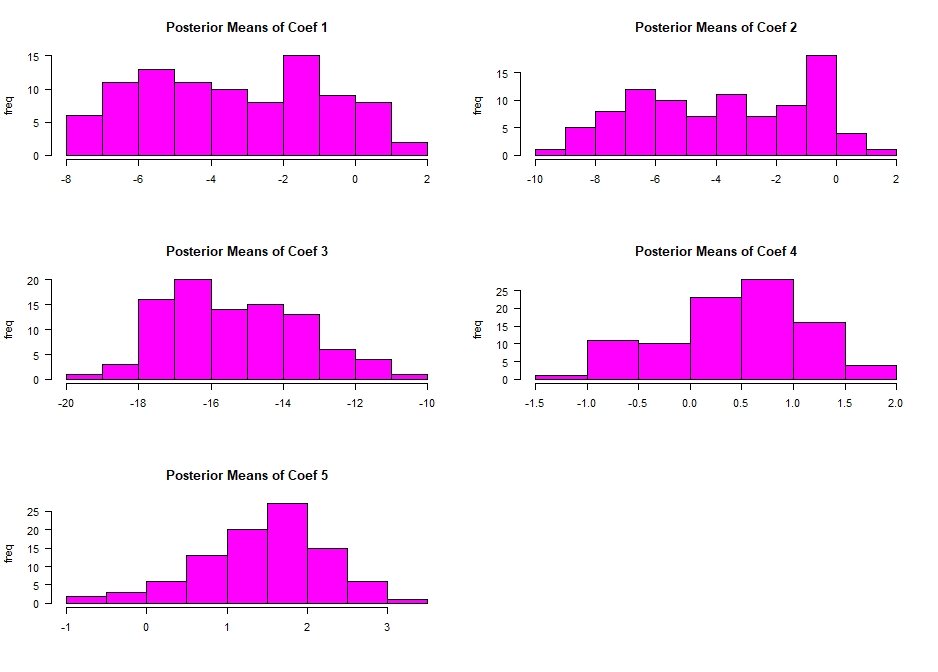

```r
# MCMCの設定
set.seed(1234)  # 乱数の初期値
burnin <- 1000  # burn-in 期間
nmcmc <- 2000   # 事後分布評価サンプル数
mcmc <- list(R = burnin+nmcmc) # MCMCのサンプル数
prior <- list(ncomp = 1)  # 事前分布の設定 ⇒ 初期設定の散漫な事前分布

# MCMCサンプリング
out <- rhierMnlRwMixture(Data = dataset, Prior = prior, Mcmc = mcmc)    # MCMCの実行

# 観測モデル回帰係数のグラフ出力
plot(out$betadraw)
```

**図 消費者別の回帰係数のヒストグラム**

（Coef 1・2：ブランド切片，Coef 3：価格，Coef 4：山積み陳列，Coef 5：チラシ）

#### 消費者パネル別回帰係数（観測モデル）

```r
# 事後平均・標準偏差の計算
beta.mean <- matrix(0, n, 5)  # 5は切片を含む回帰係数の数
beta.sd <- matrix(0, n, 5)
for (i in 1:n) {
  beta.mean[i,] <- apply(out$betadraw[i,,-(1:burnin)], 1, mean) # burn in 期間を除いた事後平均
  beta.sd[i,] <- apply(out$betadraw[i,,-(1:burnin)], 1, sd) # burn in 期間を除いた事後標準偏差
}

# 変数名の追加
rownames(beta.mean) <- id
colnames(beta.mean) <- c("Brand.1", "Brand.2", "Price", "Disp", "Ad")

# 出力
print(beta.mean)  # 全消費者の係数出力
colMeans(beta.mean) # 全消費者の係数の平均値
```

全消費者の係数出力は一部のみ表示

```
##          Brand.1   Brand.2     Price       Disp        Ad
## 100021 -4.330513 -5.021023 -13.43413  0.8613431 1.5710732
## 100072 -5.620281 -5.644132 -18.09521  1.4328226 1.6063321
## 100092  1.170359 -2.152157 -13.62498 -0.3729685 0.0475677
## 100118 -7.448030 -8.524384 -14.63080  0.4141316 1.2724433
## 100161 -4.528348 -3.616834 -15.46045  0.8896746 2.2711513
## 100176 -6.300447 -6.380072 -16.93652  0.2766000 2.5363767
##     Brand.1     Brand.2       Price        Disp          Ad
##  -3.5096201  -3.8810214 -15.5512671   0.4208998   1.4390347
```

#### 属性の影響（階層モデル）

```r
# 事後平均・標準偏差の計算
Delta.mean <- t(matrix(apply(out$Deltadraw[-(1:burnin),], 2, mean), ncol = 5))
Delta.sd <- t(matrix(apply(out$Deltadraw[-(1:burnin),], 2, sd), ncol = 5))

# 変数名の追加
rownames(Delta.mean) <- c("Brand.1", "Brand.2", "Price", "Disp", "Ad")
colnames(Delta.mean) <- c("age", "family")
rownames(Delta.sd) <- c("Brand.1", "Brand.2", "Price", "Disp", "Ad")
colnames(Delta.sd) <- c("age", "family")

# 出力
print(Delta.mean)
print(Delta.sd)
```

```
##                 age      family
## Brand.1  0.02370043  0.03572861
## Brand.2  0.06089274  0.04798064
## Price   -0.05372390 -0.49433479
## Disp    -0.65240747 -0.95071988
## Ad       0.12384078 -0.20139134
##                age     family
## Brand.1 0.04420054 0.04734354
## Brand.2 0.10359575 0.02253847
## Price   0.03183549 0.27343146
## Disp    0.29222964 0.49934388
## Ad      0.14462768 0.25872401
```

#### 参考文献

- [岩波データサイエンス刊行委員会編 (2015) 『岩波データサイエンス Vol.1 特集：ベイズ推論とMCMCのフリーソフト』岩波書店](https://www.iwanami.co.jp/book/b258169.html)
- [松原望 (2017) 『ベイズ統計学』（やさしく知りたい先端科学シリーズ）創元社](https://www.sogensha.co.jp/productlist/detail?id=3815)
- [Rossi, P. E., G. M. Allenby and R. McCulloch (2006), Bayesian Statistics and Marketing, Wiley](https://onlinelibrary.wiley.com/doi/book/10.1002/0470863692)